# Class 3 Lecture Demo

NINT5423 | Fall 2023

### Class 3 Agenda:

- [Link to Agenda](https://gis-nspe-tns.github.io/GIS_NINT5423_spring_2023/agendas/c3_agenda_spring_23_NINT5423.html)

### Class 2 Demonstration Labs:

- Lecture Demo 1 - CARTO Analysis
- Lecture Demo 2 - Selecting data with SQL
- Lecture Demo 3 - Updating data with SQL

### Lecture Demo 1: CARTO Analysis

- Download Class 3 inclass data located for direct download [HERE](https://www.dropbox.com/s/ym6c59hbxosk9qo/c3_inclass-data.zip?dl=1).

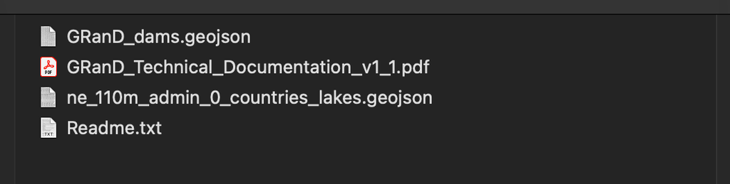

Class 3 datasources - Global Dams Points + Country Polygons

> Note: directory contains `.geojson` and additional `.pdf` and `.txt` data documentation. Documentation is useful to understand variables and sources, which in turn can help formulate SQL queries.
- Unzip the inclass data, then upload the `GRanD_dams.geojson` data to your own Carto account. The `ne_110m_admin_0_countries_lakes.geojson` polygon dataset is useful for testing PostGIS `area` statements as introduced in the lecture; however, it is not needed in this demonstration now.
- Make a map in CARTO with the global dams data and point to the Analysis subsection:

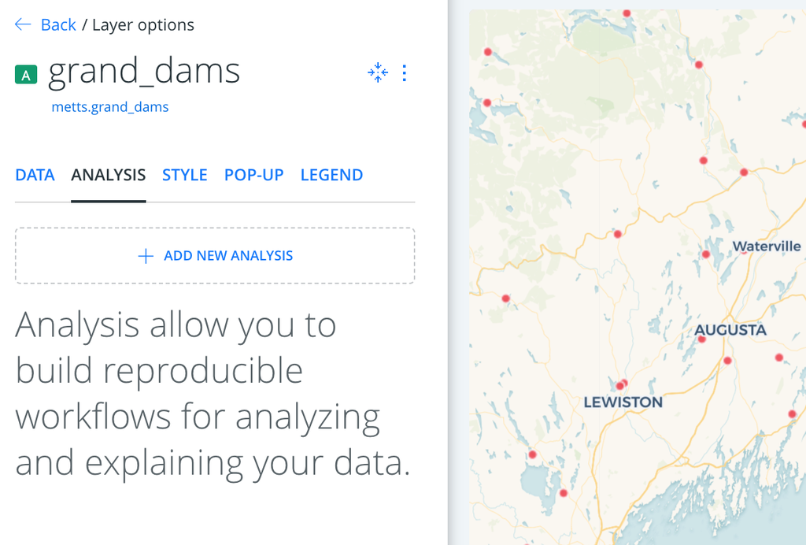

- Select `Filter by Column Value` analysis option:

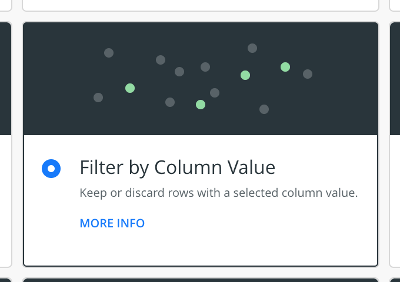

Filter by Column Value

- Select `main_use` as `Irrigation` as the filter condition:

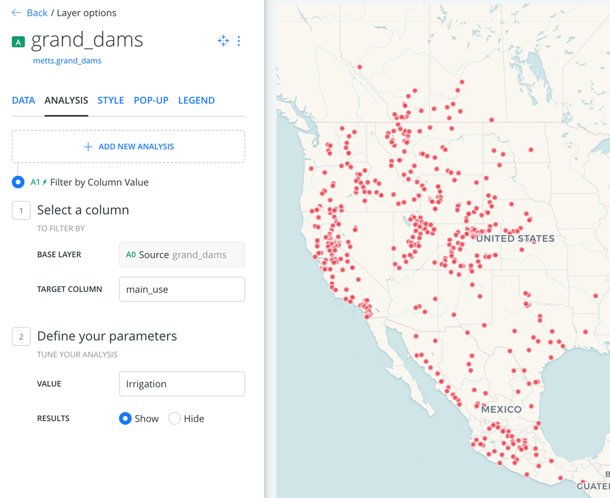

Filter set to `main_use` as `Irrigation`

### Lecture Demo 2 - Selecting data with SQL

- First, access the [SQL Cheatsheet](https://gis-nint4523.s3.us-east-2.amazonaws.com/pdf-materials/sql-cheatsheet.pdf)
- Return to the Global Dams dataset, delete the previous analysis filter, and toggle to DATA view in the CARTO interface. Point to the SQL panel utilizing the `VALUES > SQL` slider at bottom of panel.
- Execute the following Queries utilizing SQL:
- How many dams are there?

```css
SELECT COUNT(*) FROM table
```

- Which dams are in Japan?

```css
SELECT * FROM table
WHERE country = 'Japan'
```

- How many dams are mainly used for irrigation?

```css
SELECT COUNT(*) FROM table
WHERE main_use = 'Irrigation'
```

- How many dams were built before 1900?

> Note: `-99` values represent no year recorded for a particular dam in the dataset. We remove those records in the following query statement:

```css
SELECT COUNT(*) FROM table
WHERE year < 1900 AND year != -99
```

- Which dams were built after 2000?

```css
SELECT * FROM table
WHERE  year > 2000
```

### Lecture Demo 3 - Updating data with SQL

- Clear all SQL statements from previous Demo 2.
- Add a new column interactively in CARTO table view; name it `quality_display`, and make it a string field.
- Put a more readable value in our new column based on the quality column. We can separate each value assignment by a `;`:

```css
UPDATE table
SET quality_display = 'Verified'
WHERE quality = '1: Verified';
UPDATE table
SET quality_display = 'Good'
WHERE quality = '2: Good';
UPDATE table
SET quality_display = 'Fair'
WHERE quality = '3: Fair';
UPDATE table
SET quality_display = 'Poor'
WHERE quality = '4: Poor';
UPDATE table
SET quality_display = 'Unreliable'
WHERE quality = '5: Unreliable'
```

- Check that all records have been assigned the new qualitative values correctly, i.e. there are no resulting `null` values in the new `quality_display` column:

```css
SELECT DISTINCT(quality_display) FROM table
```